# Ed Sheeran

Author

FIlip Cermak

# Lets talk about Ed Sheeran!

## Who is Ed Sheeran

Ed Sheeran is a British singer-songwriter, born on February 17, 1991, in Halifax, England. He gained fame for his unique blend of pop, folk, and acoustic music. Sheeran’s rise to prominence began in 2011 with his debut studio album, “+” (Plus), featuring hits like “The A Team” and “Lego House.” His heartfelt lyrics and catchy melodies resonated with audiences, leading to multiple chart-topping albums, including “x” (Multiply), “÷” (Divide), and “No.6 Collaborations Project.”

Sheeran is known for his versatility, collaborating with various artists across genres, from Taylor Swift to Justin Bieber. He has received numerous awards, including several Grammy Awards, and is celebrated for his live performances, often incorporating loop pedals and engaging storytelling. Beyond music, Sheeran has ventured into acting and philanthropy. His impact on the music industry and culture is significant, making him one of the most recognizable and influential artists of his generation.

## Ed Sheeran Quote

“What didn’t kill me, it didn’t make me stronger at all.”

## His Albums

1. **“+” (“Plus”)** - Released on September 9, 2011
2. **“×” (“Multiply”)** - Released on June 20, 2014
3. **“÷” (“Divide”)** - Released on March 3, 2017
4. **“No.6 Collaborations Project”** - Released on July 12, 2019
5. **“=” (“Equals”)** - Released on October 29, 2021
6. **“-” (“Subtract”)** - Released on May 5, 2023

## My Pic

My favorite album

[figure not shown]

## My Favorite Song

[Take It Back (2014, youtube link)](https://www.youtube.com/watch?v=jtnyOhhs7mw)

[video not shown]

## Favorite Lyrics

(Knock, knock, knock) on my hotel door  
I don’t even know if she knows what for  
She was crying on my shoulder, I already told ya  
Trust and respect is what we do this for  
I never intended to be next (You bastard)  
But you didn’t need to take him to bed, that’s all  
And I never saw him as a threat (You bastard)  
Until you disappeared with him to have sex, of course  
It’s not like we were both on tour  
We were staying on the same fucking hotel floor  
And I wasn’t looking for a promise or commitment  
But it was never just fun, and I thought you were different  
This is not the way you realized what you wanted  
It’s a bit too much, too late, if I’m honest  
And all this time, God knows I’m singing

```r
# These are packages I need for the analysis
#options(repos = c(CRAN = "https://cran.rstudio.com/"))
#install.packages("ggplot2")  # Example package
#install.packages("ggplot2")
#install.packages("dplyr")

# These are packages I need for the analysis
#install.packages("ggplot2")
#install.packages("dplyr")
library(ggplot2)
library(dplyr)

# Import info data df
df <- read.csv("Ed Sheeran.csv")

# Slice 5 random recodrs in the dataframe
df|> dplyr:: slice_sample(n=5) |> knitr::kable(digits = 2)
```

| artist_name | track_name | track_number | album_name | album_release_year | energy | valence | danceability | loudness | speechiness | liveness | tempo | key_mode | duration_ms |
| --- | --- | --- | --- | --- | --- | --- | --- | --- | --- | --- | --- | --- | --- |
| Ed Sheeran | Cross Me (feat. Chance the Rapper & PnB Rock) | 3 | No.6 Collaborations Project | 2019 | 0.79 | 0.61 | 0.75 | -6.37 | 0.12 | 0.07 | 95.00 | E major | 206186 |
| Ed Sheeran | Punchline | 11 | Autumn Variations (Fan Living Room Sessions) | 2023 | 0.41 | 0.62 | 0.53 | -7.99 | 0.03 | 0.11 | 154.06 | B major | 206008 |
| Ed Sheeran | Welcome To The World | 19 | = (Tour Edition) | 2022 | 0.31 | 0.43 | 0.33 | -8.52 | 0.03 | 0.36 | 169.53 | C major | 176813 |
| Ed Sheeran | Supermarket Flowers | 12 | ÷ (Deluxe) | 2017 | 0.24 | 0.26 | 0.59 | -10.52 | 0.04 | 0.09 | 89.75 | F# major | 221106 |
| Ed Sheeran | The Hills of Aberfeldy | 14 | - (Deluxe) | 2023 | 0.19 | 0.33 | 0.44 | -7.69 | 0.03 | 0.10 | 79.57 | G major | 195083 |

```r
# Slice 5 random records in the data frame
df |> dplyr :: slice_sample(n=5)|> knitr::kable(digits = 2)
```

| artist_name | track_name | track_number | album_name | album_release_year | energy | valence | danceability | loudness | speechiness | liveness | tempo | key_mode | duration_ms |
| --- | --- | --- | --- | --- | --- | --- | --- | --- | --- | --- | --- | --- | --- |
| Ed Sheeran | 2step (feat. Ultimo) | 2 | 2step (The Remixes) | 2021 | 0.69 | 0.69 | 0.73 | -5.06 | 0.07 | 0.14 | 94.94 | E minor | 154160 |
| Ed Sheeran | New Man | 8 | ÷ (Deluxe) | 2017 | 0.74 | 0.86 | 0.78 | -3.97 | 0.14 | 0.06 | 94.03 | G major | 189280 |
| Ed Sheeran | England | 2 | Autumn Variations (Fan Living Room Sessions) | 2023 | 0.67 | 0.52 | 0.62 | -10.79 | 0.04 | 0.51 | 126.93 | F major | 226756 |
| Ed Sheeran | Kiss Me | 11 | + | 2011 | 0.23 | 0.18 | 0.59 | -16.67 | 0.05 | 0.02 | 74.99 | D major | 280853 |
| Ed Sheeran | The A Team | 1 | + | 2011 | 0.29 | 0.41 | 0.64 | -9.92 | 0.04 | 0.18 | 85.00 | A major | 258373 |

## Data Preparation

Since there are some duplicated tracks, I’ve cleaned them. Also, I’ve removed the tracks in the live versions of the same songs.

```r
# Install dplyr if not already installed
# install.packages("dplyr")

# Load the dplyr package
library(dplyr)

# Remove records with the same track names
df <- df |> distinct(track_name, .keep_all = TRUE)
#Filter out track names that include "Live at" or "Live Acoustic"
df <- df |> filter(!grepl("Live at|Live Acoustic", track_name))
#Chnage the data type of album_name from numeric into character
df$album_name <- as.character(df$album_name)
```

## Album Analysis (valence)

Let’s see how are Ed’s albums doing in regards to valence

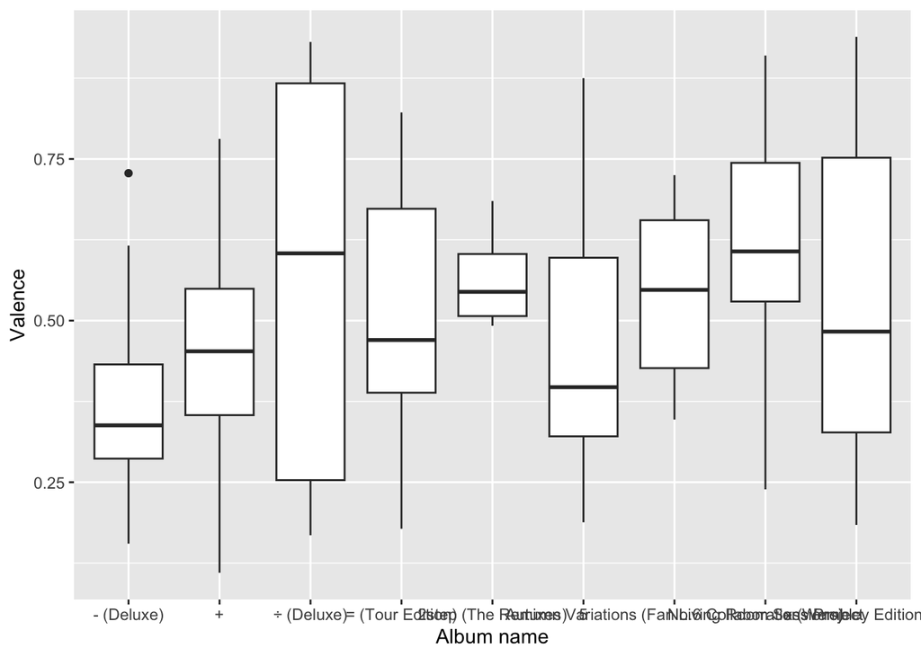

```r
# Install ggplot2 if not already installed
# install.packages("ggplot2")

# Load the ggplot2 package
library(ggplot2)
# Change album_name from character to factor before plotting
df$album_name <- as.factor(df$album_name)
#Plot a boxplot
ggplot(df, aes(x=album_name,y=valence))+
  geom_boxplot()+
  labs(x="Album name", y="Valence")
```

## Ed Sheeran’s most positive song

Let’s look at the 3 most positive songs of his.

```r
# Load necessary libraries
library(dplyr)
library(knitr)

df |> slice_max(valence, n=3) |> dplyr::select(track_name, album_name, album_release_year, valence) |> knitr::kable(digits = 2)
```

| track_name | album_name | album_release_year | valence |
| --- | --- | --- | --- |
| Sing | x (Wembley Edition) | 2015 | 0.94 |
| Shape of You | ÷ (Deluxe) | 2017 | 0.93 |
| Eraser | ÷ (Deluxe) | 2017 | 0.91 |

Now let’s look at the 3 most energetic songs:

```r
# Load necessary libraries
library(dplyr)
library(knitr)
df |> slice_max(energy, n=3) |> dplyr::select(track_name, album_name, album_release_year, energy)|> knitr::kable(digits = 2)
```

| track_name | album_name | album_release_year | energy |
| --- | --- | --- | --- |
| Drown Me Out (feat. Ghetts) - + Ghetts | 5 | 2014 | 0.91 |
| Bad Habits | = (Tour Edition) | 2022 | 0.89 |
| Galway Girl | ÷ (Deluxe) | 2017 | 0.88 |

Let’s listen to ‘Sing’

[video not shown]

## The Controversy

Ed has been accused in recent years that he went from a busker and authentic singer to a hit maker. His fans have especially criticized his album ‘=’ for being aimed at party listeners and being a ‘cheap dance pop’. Let’s see if Ed’s albums actually get more danceable in time.

```r
# Load necessary libraries
library(dplyr)    # For data manipulation
library(ggplot2)  # For plotting

df1 <- read.csv("Jeff Buckley.csv")
df2 <- read.csv("Olivia Rodrigo.csv")

# Combine datasets with a new column to identify the source
df_combined <- df %>% mutate(Source = "Ed Sheeran") %>%
  bind_rows(df1 %>% mutate(Source = "Jeff Buckley")) %>%
  bind_rows(df2 %>% mutate(Source = "Olivia Rodrigo"))

# Check the structure of the combined dataset
str(df_combined)
```

```
'data.frame':   230 obs. of  19 variables:
 $ artist_name       : chr  "Ed Sheeran" "Ed Sheeran" "Ed Sheeran" "Ed Sheeran" ...
 $ track_name        : chr  "1000 Nights (feat. Meek Mill & A Boogie Wit da Hoodie)" "2step" "2step (feat. 1.Cuz)" "2step (feat. Antytila)" ...
 $ track_number      : int  13 9 7 4 14 8 10 13 6 5 ...
 $ album_name        : chr  "No.6 Collaborations Project" "= (Tour Edition)" "2step (The Remixes)" "2step (The Remixes)" ...
 $ album_release_year: int  2019 2022 2021 2021 2021 2021 2021 2021 2021 2021 ...
 $ energy            : num  0.589 0.661 0.663 0.695 0.667 0.621 0.642 0.69 0.741 0.701 ...
 $ valence           : num  0.513 0.632 0.617 0.599 0.508 0.565 0.504 0.492 0.615 0.522 ...
 $ danceability      : num  0.778 0.763 0.674 0.506 0.747 0.727 0.731 0.728 0.705 0.73 ...
 $ loudness          : num  -5.55 -5.59 -5.08 -5.18 -5.18 ...
 $ speechiness       : num  0.269 0.056 0.084 0.105 0.0566 0.0555 0.0695 0.084 0.0683 0.0447 ...
 $ liveness          : num  0.0902 0.117 0.13 0.151 0.146 0.114 0.242 0.113 0.216 0.0657 ...
 $ tempo             : num  98 95 94.8 93.8 95 ...
 $ key_mode          : chr  "G# major" "E minor" "G major" "E minor" ...
 $ duration_ms       : int  212306 153626 153226 153213 153124 153426 164560 153227 153373 154453 ...
 $ Source            : chr  "Ed Sheeran" "Ed Sheeran" "Ed Sheeran" "Ed Sheeran" ...
 $ album_release_date: chr  NA NA NA NA ...
 $ instrumentalness  : num  NA NA NA NA NA NA NA NA NA NA ...
 $ key_name          : chr  NA NA NA NA ...
 $ mode_name         : chr  NA NA NA NA ...
```

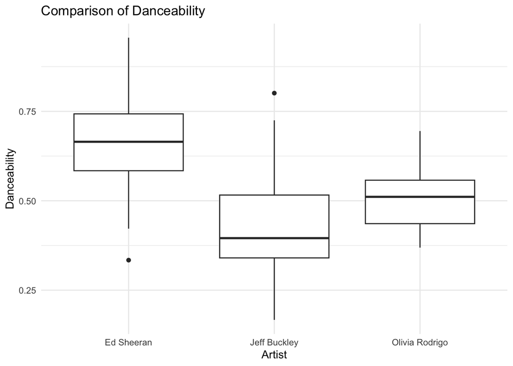

```r
# Create a boxplot to compare danceability across the three datasets
ggplot(df_combined, aes(x = Source, y = danceability)) +
  geom_boxplot() +
  labs(title = "Comparison of Danceability", x = "Artist", y = "Danceability") +
  theme_minimal()
```

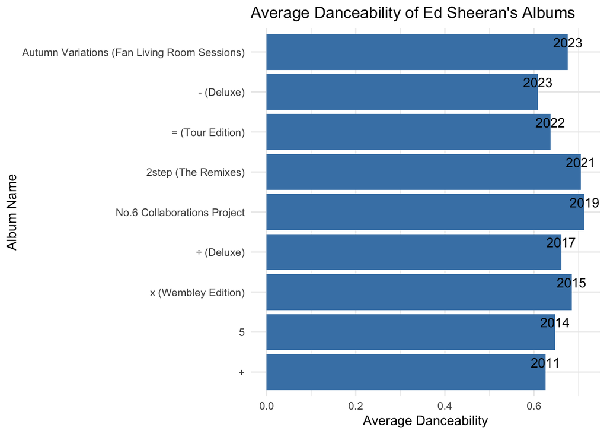

```r
# Load necessary libraries
library(dplyr)   # For data manipulation
library(ggplot2) # For plotting

# Summarize the data to get the average danceability for each album
danceability_summary <- df %>%
  group_by(album_name, album_release_year) %>%
  summarize(average_danceability = mean(danceability, na.rm = TRUE), .groups = "drop") %>%
  arrange(album_release_year)  # Order by the correct release year column

# Create a bar chart comparing the danceability of Ed Sheeran's albums
ggplot(danceability_summary, aes(x = reorder(album_name, album_release_year), y = average_danceability)) +
  geom_bar(stat = "identity", fill = "steelblue") +
  geom_text(aes(label = album_release_year), vjust = -0.5) +  # Add release year labels above the bars
  labs(title = "Average Danceability of Ed Sheeran's Albums",
       x = "Album Name",
       y = "Average Danceability") +
  theme_minimal() +
  coord_flip()  # Flips the coordinates for better readability if there are many albums
```

From this graph the accusations seem unsound as the ‘=’ album that was most look down upon for its adaptability is one if the least danceable ones.

While some say Ed is an authentic song writer such as for example Jeff Buckley, others claim Ed is aiming for his music to be ‘likable’ dance music such as Olivia Rodrigo. Is Ed Sheeran a dance pop star or an authentic song writer?

Let’s compare the danceability in his songs with one dance pop star and one folk song writer.

Let’s compare the danceability in his songs with one dance pop star and one folk song writer.

```r
# Load necessary libraries
library(dplyr)    # For data manipulation
library(ggplot2)  # For plotting

# Combine datasets with a new column to identify the source
df_combined <- df %>% mutate(Source = "Ed Sheeran") %>%
  bind_rows(df1 %>% mutate(Source = "Jeff Buckley")) %>%
  bind_rows(df2 %>% mutate(Source = "Olivia Rodrigo"))

# Check the structure of the combined dataset
str(df_combined)
```

```
'data.frame':   230 obs. of  19 variables:
 $ artist_name       : chr  "Ed Sheeran" "Ed Sheeran" "Ed Sheeran" "Ed Sheeran" ...
 $ track_name        : chr  "1000 Nights (feat. Meek Mill & A Boogie Wit da Hoodie)" "2step" "2step (feat. 1.Cuz)" "2step (feat. Antytila)" ...
 $ track_number      : int  13 9 7 4 14 8 10 13 6 5 ...
 $ album_name        : chr  "No.6 Collaborations Project" "= (Tour Edition)" "2step (The Remixes)" "2step (The Remixes)" ...
 $ album_release_year: int  2019 2022 2021 2021 2021 2021 2021 2021 2021 2021 ...
 $ energy            : num  0.589 0.661 0.663 0.695 0.667 0.621 0.642 0.69 0.741 0.701 ...
 $ valence           : num  0.513 0.632 0.617 0.599 0.508 0.565 0.504 0.492 0.615 0.522 ...
 $ danceability      : num  0.778 0.763 0.674 0.506 0.747 0.727 0.731 0.728 0.705 0.73 ...
 $ loudness          : num  -5.55 -5.59 -5.08 -5.18 -5.18 ...
 $ speechiness       : num  0.269 0.056 0.084 0.105 0.0566 0.0555 0.0695 0.084 0.0683 0.0447 ...
 $ liveness          : num  0.0902 0.117 0.13 0.151 0.146 0.114 0.242 0.113 0.216 0.0657 ...
 $ tempo             : num  98 95 94.8 93.8 95 ...
 $ key_mode          : chr  "G# major" "E minor" "G major" "E minor" ...
 $ duration_ms       : int  212306 153626 153226 153213 153124 153426 164560 153227 153373 154453 ...
 $ Source            : chr  "Ed Sheeran" "Ed Sheeran" "Ed Sheeran" "Ed Sheeran" ...
 $ album_release_date: chr  NA NA NA NA ...
 $ instrumentalness  : num  NA NA NA NA NA NA NA NA NA NA ...
 $ key_name          : chr  NA NA NA NA ...
 $ mode_name         : chr  NA NA NA NA ...
```

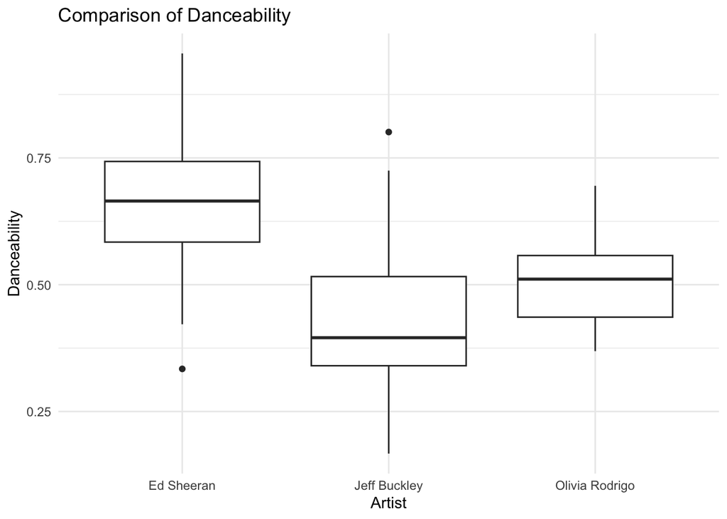

```r
# Create a boxplot to compare danceability across the three datasets
ggplot(df_combined, aes(x = Source, y = danceability)) +
  geom_boxplot() +
  labs(title = "Comparison of Danceability", x = "Artist", y = "Danceability") +
  theme_minimal()
```

This chart shows that Ed’s music is not only more danceable than Jeff Buckley’s music, but it is even more danceable than music of Olivia Rodrigo. Shocking!! Ed might just be a hitmaker after all:(

Lastly, most of Ed’s music has been influenced by his relationships and breakups. His. fans say he is a family type and does’t cope well with breakups. Is it true that Ed makes a more lively, energetic and faster pace music when he is in a relationship than when he is single?

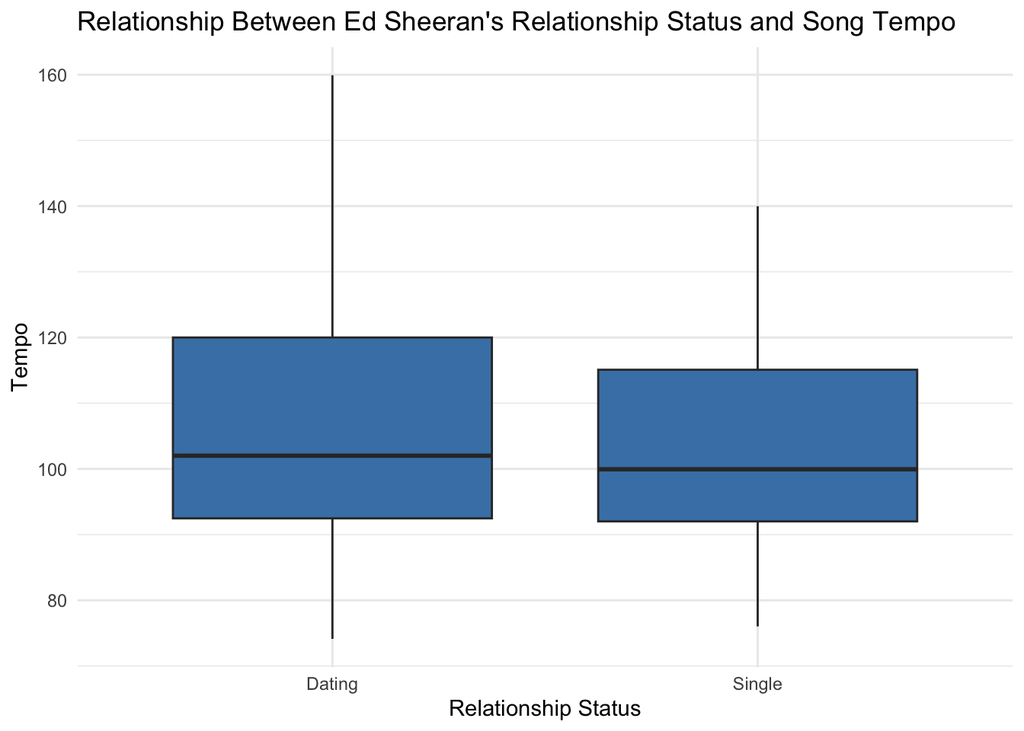

```r
# Load necessary libraries
library(dplyr)   # For data manipulation
library(ggplot2) # For plotting
library(readr)

# Load Ed Sheeran's song dataset
ed_sheeran_data <- read_csv("Ed Sheeran.csv")  # Adjust the file path as needed
relationship_data <- read_csv("relationship_data.csv")

# Create a new column for relationship status based on the album release year
ed_sheeran_data <- ed_sheeran_data %>%
  left_join(relationship_data, by = character()) %>%
  mutate(Status = ifelse(album_release_year >= as.integer(format(Start_Date,"%Y")) &
                         album_release_year <= as.integer(format(End_Date,"%Y")),
                         Status, NA))

# Remove rows with NA Status (i.e., songs that don't fit within specified dates)
ed_sheeran_data <- ed_sheeran_data %>%
  filter(!is.na(Status))

# Create a boxplot to visualize the relationship between tempo and relationship status
ggplot(ed_sheeran_data, aes(x = Status, y = tempo)) +
  geom_boxplot(fill = "steelblue") +
  labs(title = "Relationship Between Ed Sheeran's Relationship Status and Song Tempo",
       x = "Relationship Status",
       y = "Tempo") +
  theme_minimal()
```

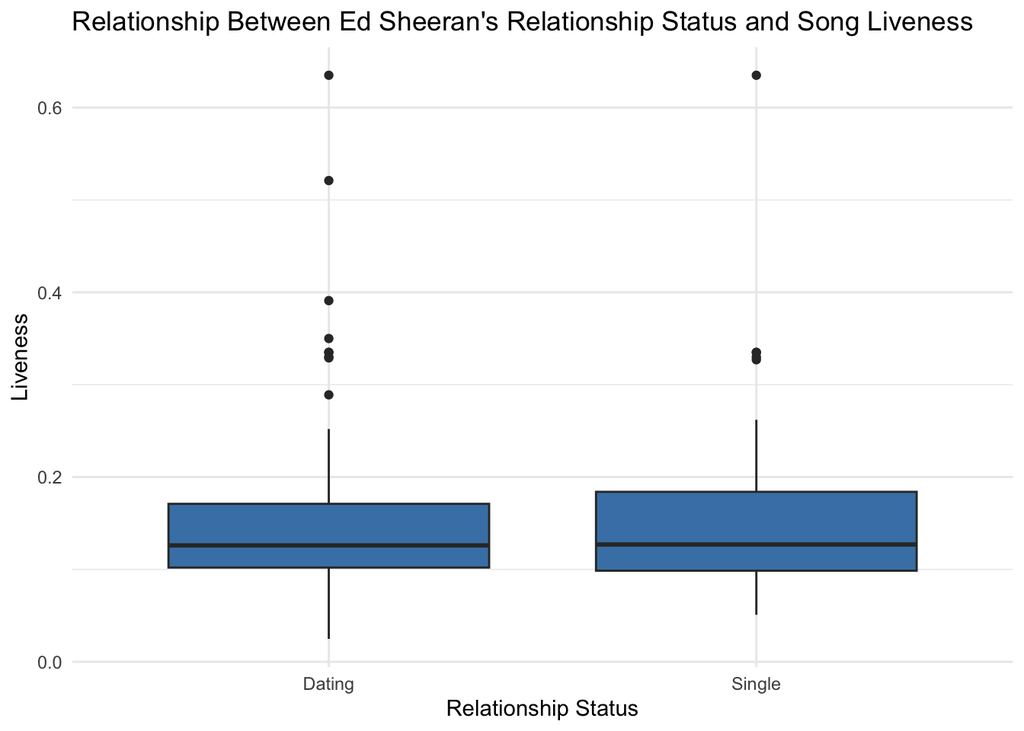

```r
# Load necessary libraries
library(dplyr)   # For data manipulation
library(ggplot2) # For plotting
library(readr)   # For reading CSV files

# Load Ed Sheeran's song dataset
ed_sheeran_data <- read_csv("Ed Sheeran.csv")  # Adjust the file path as needed

# Create relationship data frame (ensure this data frame is defined as in previous examples)
relationship_data <- data.frame(
  Start_Date = as.Date(c("2011-01-01", "2012-06-02", "2013-09-02", "2015-12-02", "2018-01-02")),
  End_Date = as.Date(c("2012-06-01", "2013-09-01", "2015-12-01", "2018-01-01", Sys.Date())),
  Status = c("Dating", "Single", "Dating", "Single", "Dating")
)

# Join the relationship data to the Ed Sheeran dataset and identify the relationship status
ed_sheeran_data <- ed_sheeran_data %>%
  left_join(relationship_data, by = character()) %>%
  mutate(Status = ifelse(album_release_year >= as.integer(format(Start_Date,"%Y")) &
                         album_release_year <= as.integer(format(End_Date,"%Y")),
                         Status, NA))

# Remove rows with NA Status (i.e., songs that don't fit within specified dates)
ed_sheeran_data <- ed_sheeran_data %>%
  filter(!is.na(Status))

# Create a boxplot to visualize the relationship between liveness and relationship status
ggplot(ed_sheeran_data, aes(x = Status, y = liveness)) +
  geom_boxplot(fill = "steelblue") +
  labs(title = "Relationship Between Ed Sheeran's Relationship Status and Song Liveness",
       x = "Relationship Status",
       y = "Liveness") +
  theme_minimal()
```

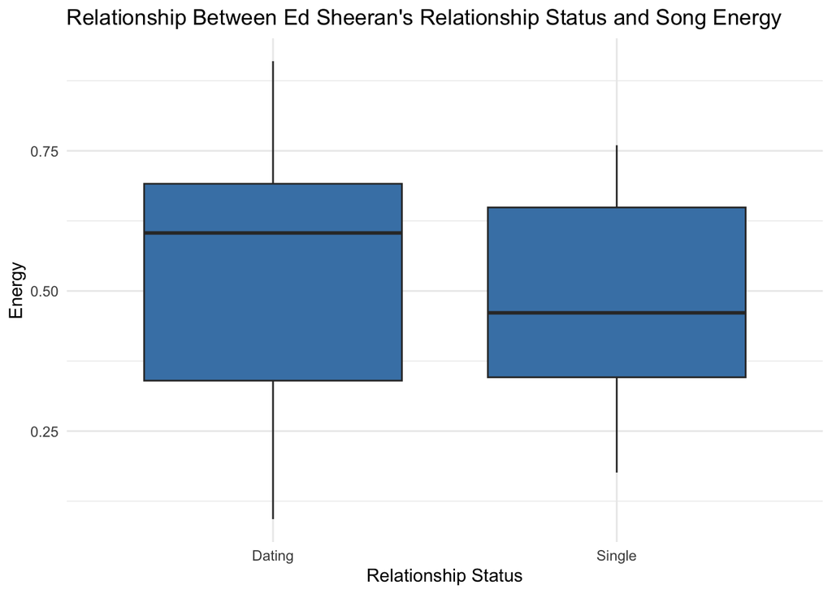

```r
# Load necessary libraries
library(dplyr)   # For data manipulation
library(ggplot2) # For plotting
library(readr)   # For reading CSV files
library(lubridate) #for date handling

# Load Ed Sheeran's song data (replace with your actual path)
ed_sheeran_data <- read_csv("Ed Sheeran.csv")

#relationship data
relationship_data <- data.frame(
  Start_Date = ymd(c("2011-01-01", "2012-06-02", "2013-09-02", "2015-12-02", "2018-01-02")),
  End_Date = ymd(c("2012-06-01", "2013-09-01", "2015-12-01", "2018-01-01", Sys.Date())),
  Status = c("Dating", "Single", "Dating", "Single", "Dating")
)

# Convert album_release_year to integer for comparison with year
ed_sheeran_data <- ed_sheeran_data %>%
  mutate(album_release_year = as.integer(album_release_year)) %>%
  mutate(rel_year = year(ymd(paste(album_release_year, "-01-01", sep = "")))) %>%
  filter(!is.na(rel_year))

# Assign relationship status based on album release year
ed_sheeran_data <- ed_sheeran_data %>%
  mutate(Status = NA_character_) %>%
  rowwise() %>%
  mutate(Status = relationship_data$Status[which.min(abs(rel_year - year(relationship_data$Start_Date)))])

# Remove rows with NA Status
ed_sheeran_data <- ed_sheeran_data %>%
  filter(!is.na(Status))

# Create a boxplot to visualize the relationship between energy and relationship status
ggplot(ed_sheeran_data, aes(x = Status, y = energy)) +  # Only change is here: y = energy
  geom_boxplot(fill = "steelblue") +
  labs(title = "Relationship Between Ed Sheeran's Relationship Status and Song Energy",  # Updated title
       x = "Relationship Status",
       y = "Energy") +  # Updated y-axis label
  theme_minimal()
```